# ПС Комсомольская

2023-01-23

## Анализ пропущенных периодов

| Начало_периода | Конец_периода | Период |
| --- | --- | --- |
| 2013-01-11 03:14:22 | 2013-01-25 22:09:28 | 14d 18H 55M 6S |
| 2013-01-25 22:13:28 | 2013-01-25 22:38:20 | 24M 52S |
| 2013-01-25 22:43:20 | 2022-06-21 12:30:00 | 3433d 14H 46M 40S |
| 2022-06-21 16:28:33 | 2022-06-21 16:30:04 | 1M 31S |
| 2022-06-30 23:59:01 | 2022-07-01 00:01:01 | 2M 0S |
| 2022-07-14 10:06:18 | 2022-07-14 10:33:18 | 27M 0S |
| 2022-07-31 23:59:02 | 2022-08-01 00:01:02 | 2M 0S |
| 2022-08-31 23:59:02 | 2022-09-01 00:01:02 | 2M 0S |
| 2022-09-30 23:59:02 | 2022-10-01 00:01:02 | 2M 0S |
| 2022-10-25 14:10:02 | 2022-10-25 14:13:02 | 3M 0S |
| 2022-10-31 23:59:02 | 2022-11-01 00:01:02 | 2M 0S |
| 2022-11-11 16:11:11 | 2022-11-11 16:14:11 | 3M 0S |
| 2022-11-30 23:59:11 | 2022-12-01 00:01:11 | 2M 0S |
| 2022-12-31 23:59:11 | 2023-01-01 00:01:11 | 2M 0S |

## Анализ непрерывных данных с периодом более 12 часов

[output not shown]

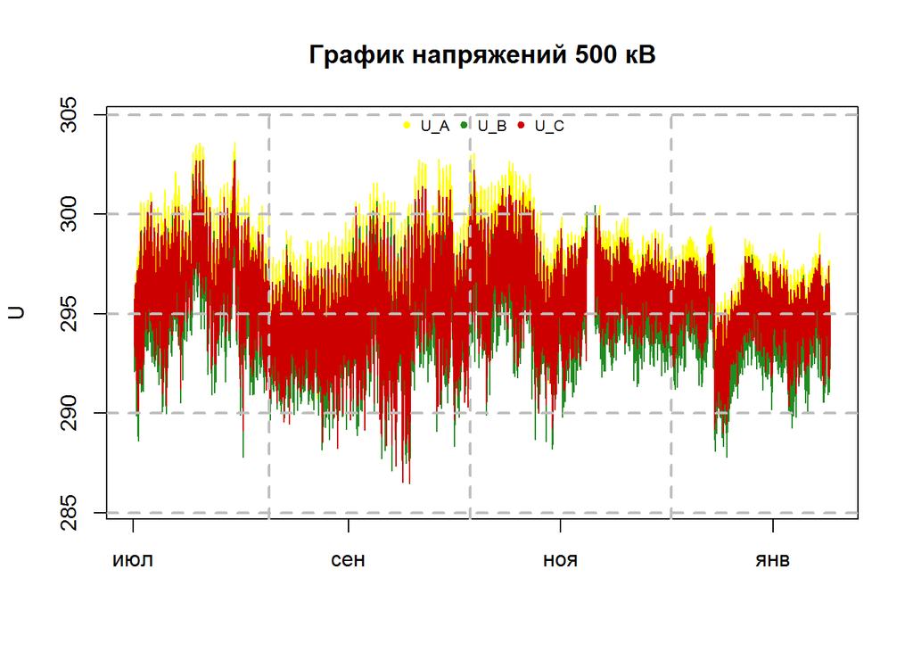

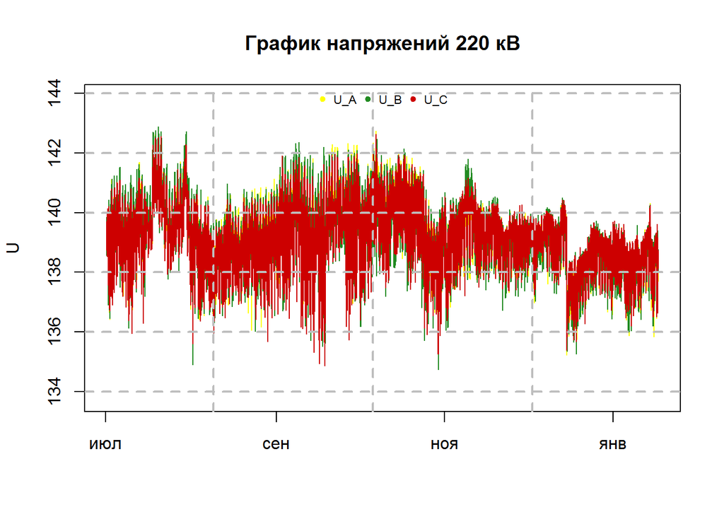

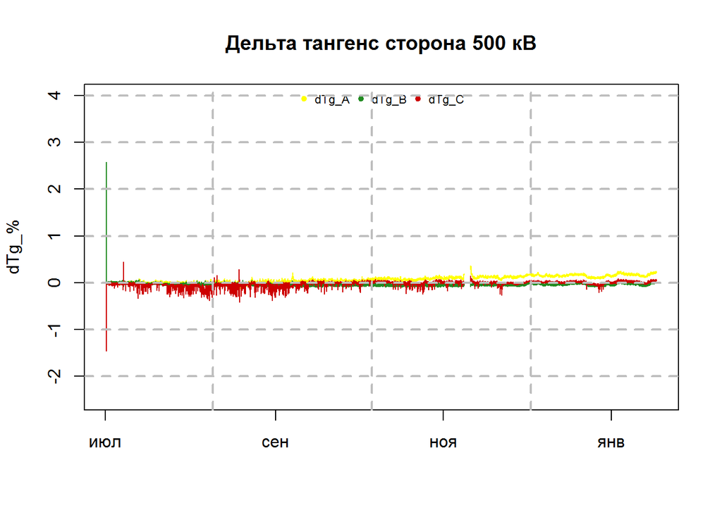

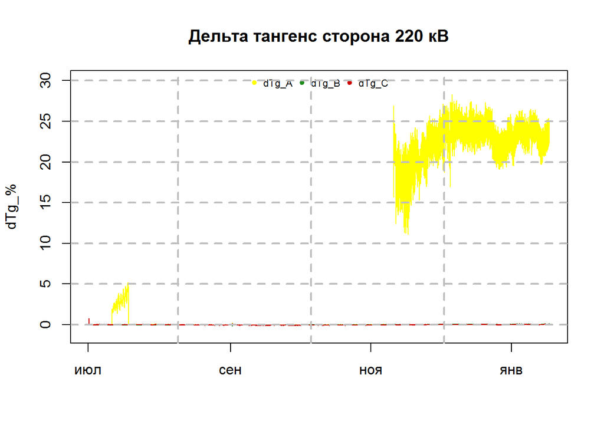

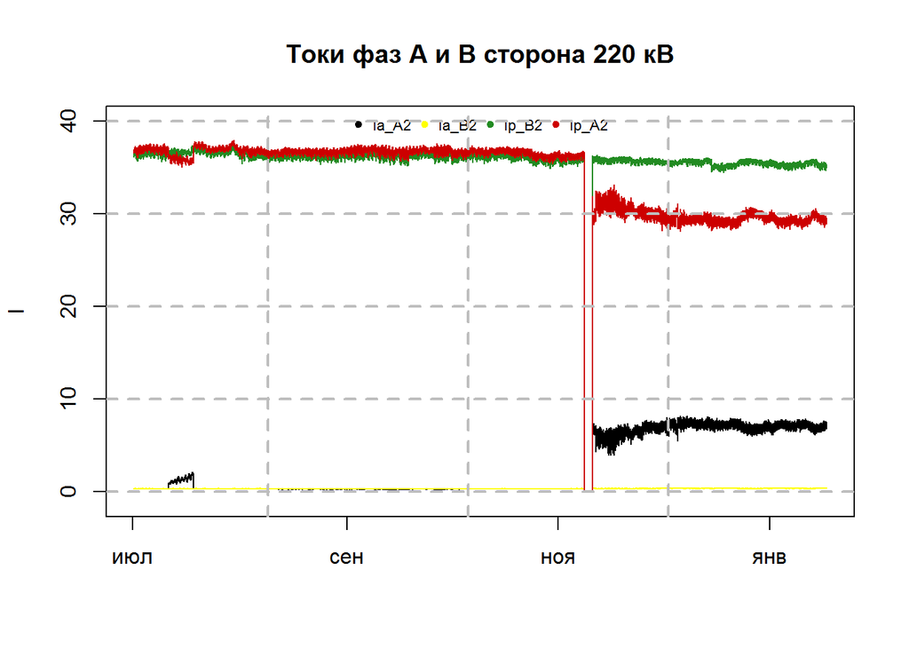

## Емкость

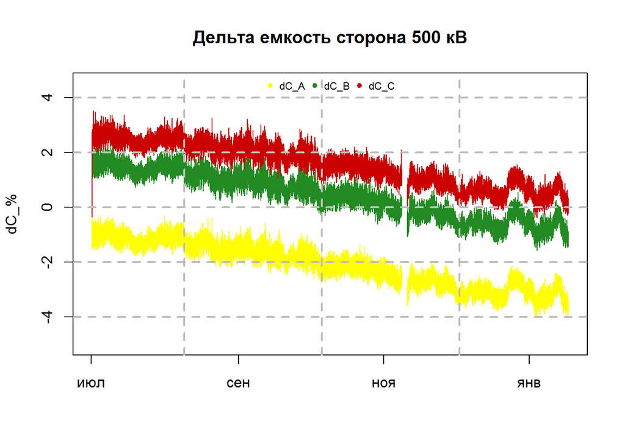

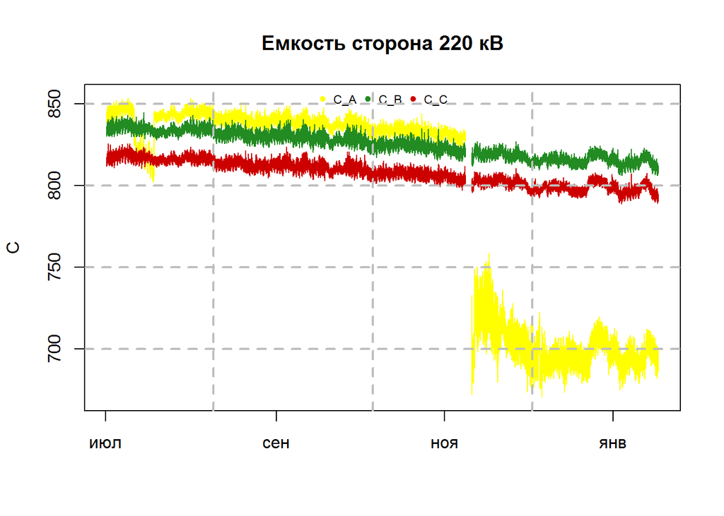

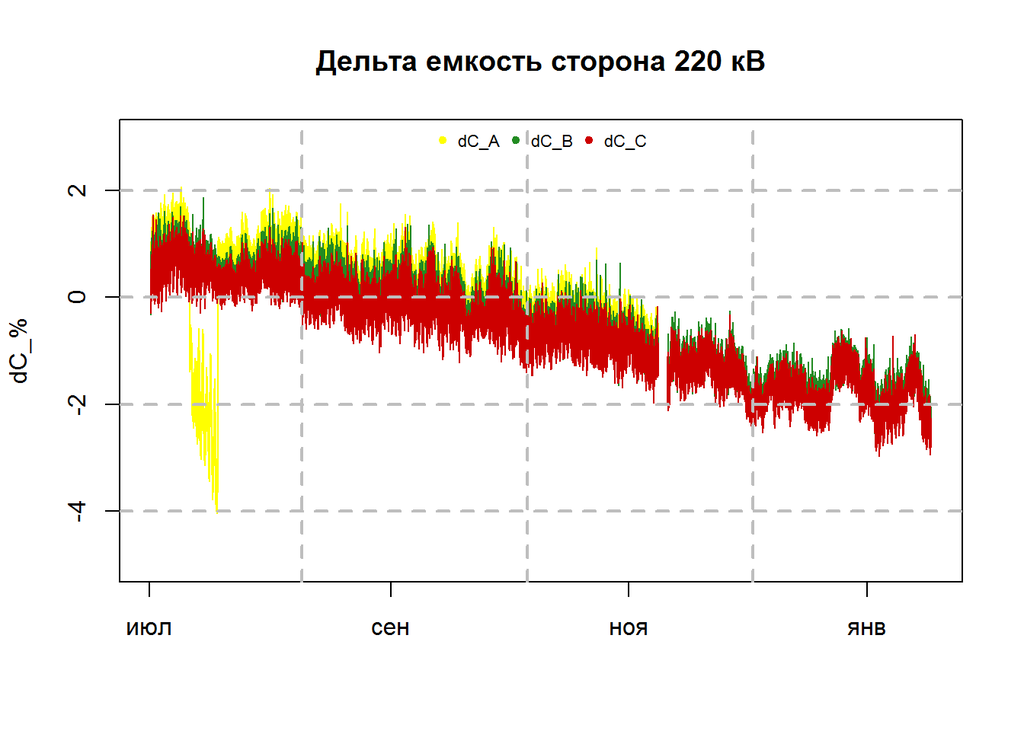

## Добавим столцы по средним емкостям по фазам А-В, В-С, С-А

Вычтем разницу между средних двух и оставшейся третьей и построим график

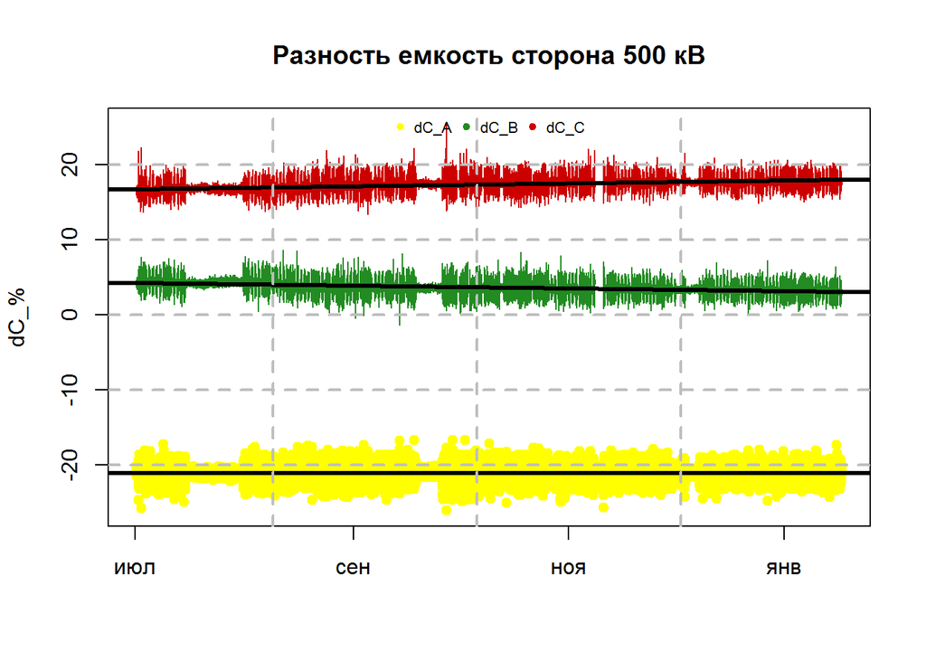

## Строим зависимости дельта емкости от температуры

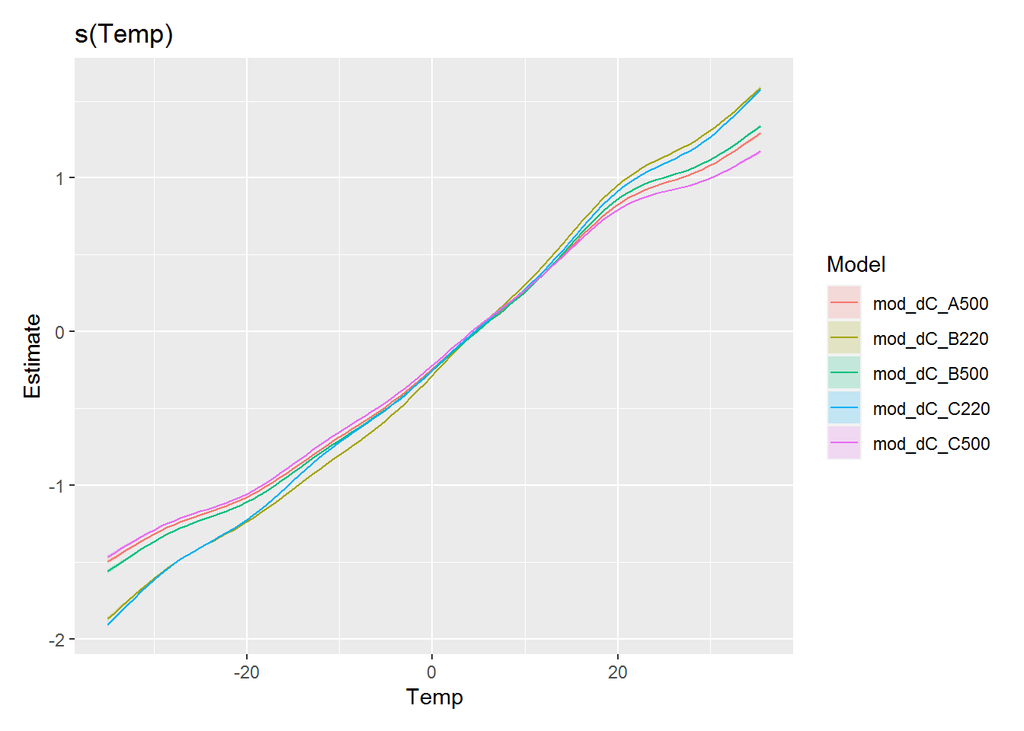

на графике прослеживается похожая зависимость с графиками моделей дельта емкости от температуры полученной с ПАО Уралкалий (см.ниже)

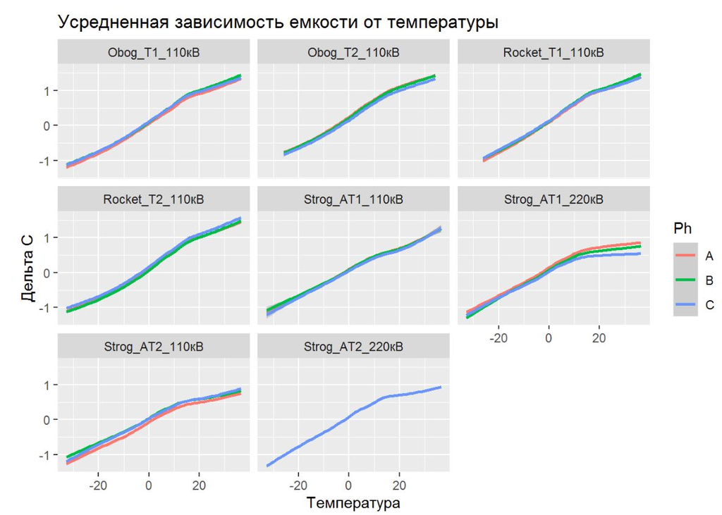

## Строим зависимости дельта тангенса от температуры

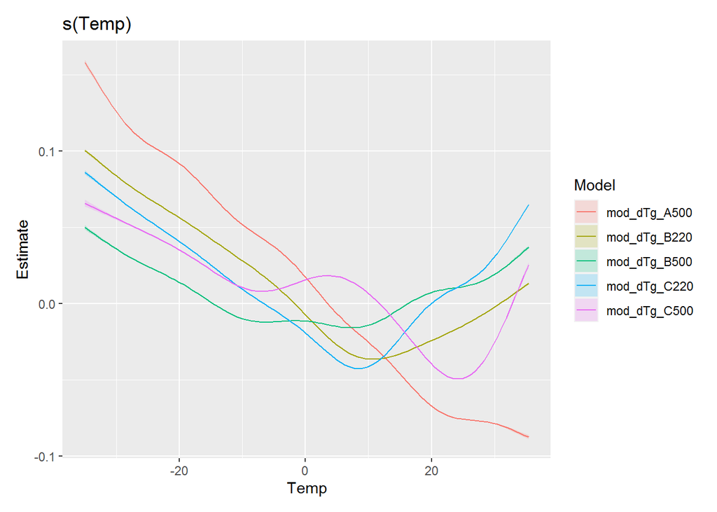

## Загружаем данные с метеостанции в Комсомольске на Амуре

**сайт:** https://rp5.ru/%D0%90%D1%80%D1%85%D0%B8%D0%B2_%D0%BF%D0%BE%D0%B3%D0%BE%D0%B4%D1%8B_%D0%B2_%D0%9A%D0%BE%D0%BC%D1%81%D0%BE%D0%BC%D0%BE%D0%BB%D1%8C%D1%81%D0%BA%D0%B5-%D0%BD%D0%B0-%D0%90%D0%BC%D1%83%D1%80%D0%B5

В представленных данных интервал записи составляет 3 часа начиная с 1:00 каждых суток Нормируем анализируемую БД НКВВ к таким интервалам и добавляем в нее данные из архива метеостанции.

**Для проверки достоверности (совпадения показаний) строим график температуры из БД НКВВ и из архива метеостанции:**

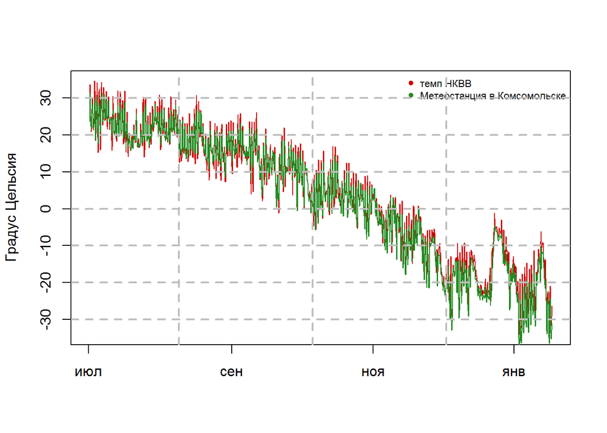

Строим модель зависимости температур от двух вышеупомянутых датчиков:

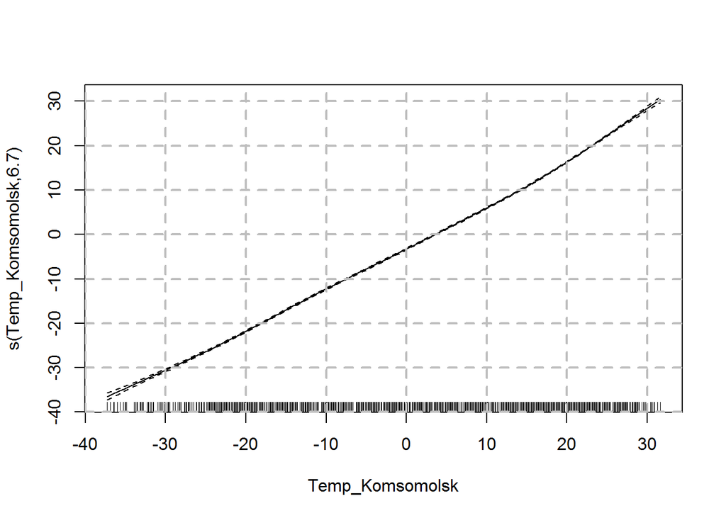

Из полученного графика четко видна корреляция данных по температуре исходя из чего можно сделать вывод что данные с датчика в Комсомольске на Амуре имеют линейную зависимость с данными датчика НКВВ

## Строим модели зависимости дельта тангенса и дельта емкости от влажности

**Строим зависимости дельта емкости от влажности**

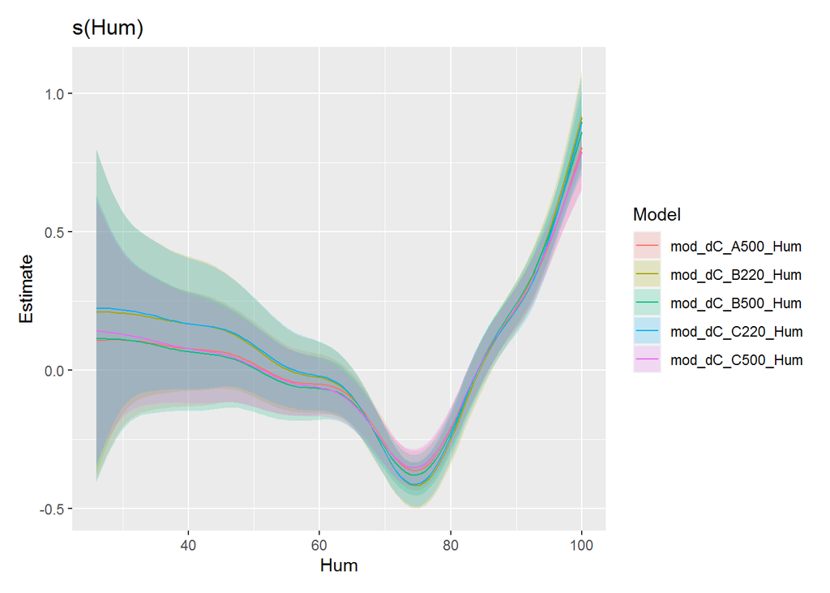

**Сторона 220 кВ**

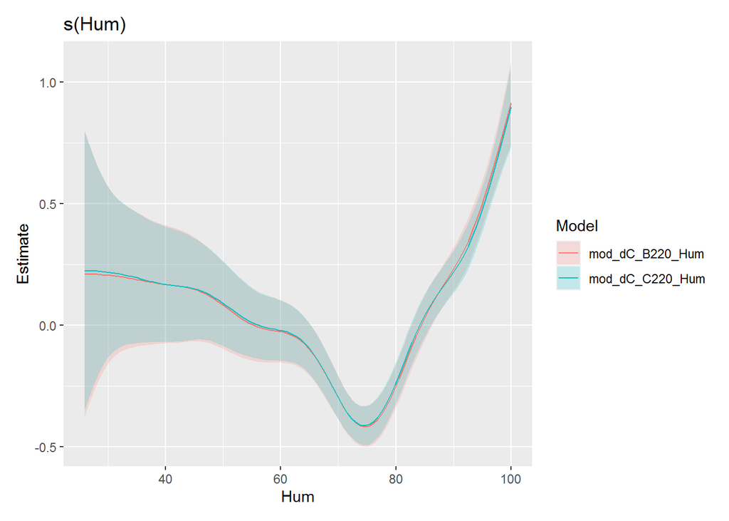

**Сторона 500 кВ**

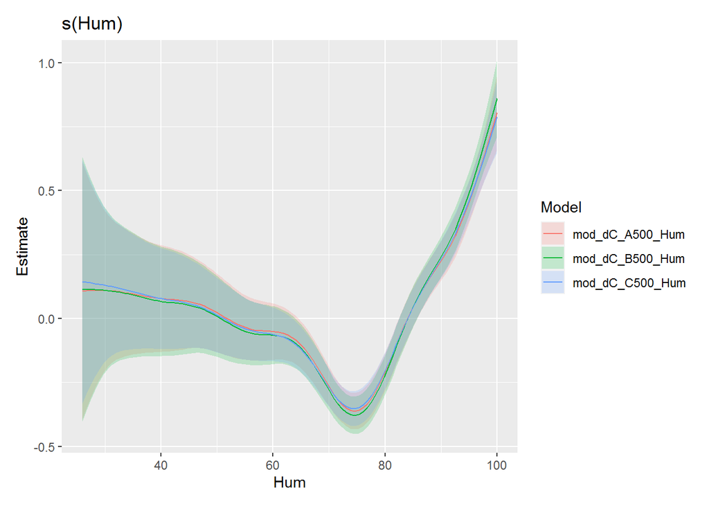

**на всех графиках прослеживается схожесть с графиками моделей дельта емкости от влажности полученной с ПАО Уралкалий (см.ниже)**

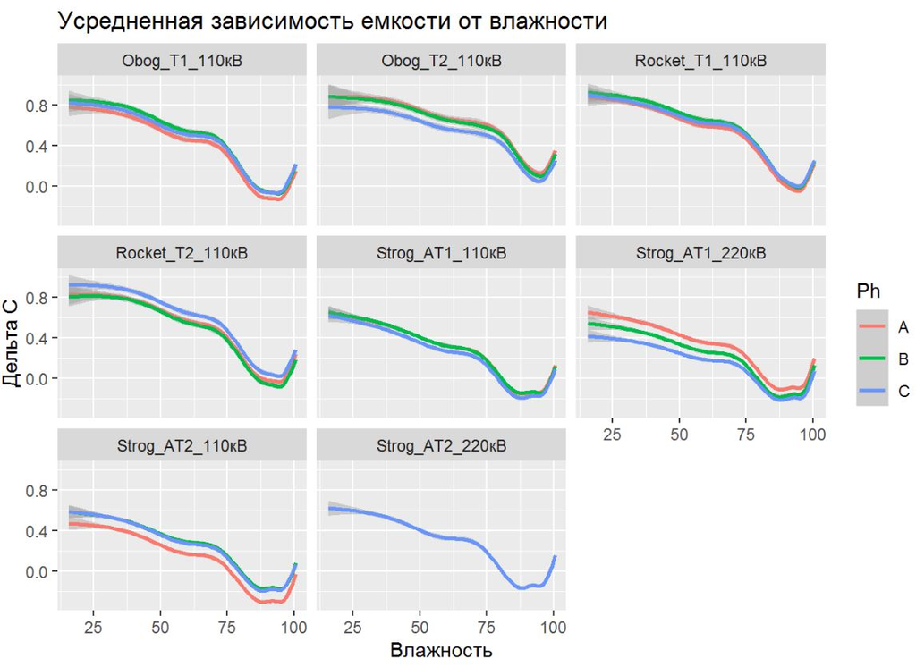

**Строим зависимости дельта тангенса от влажности**

**Сторона 220 кВ**

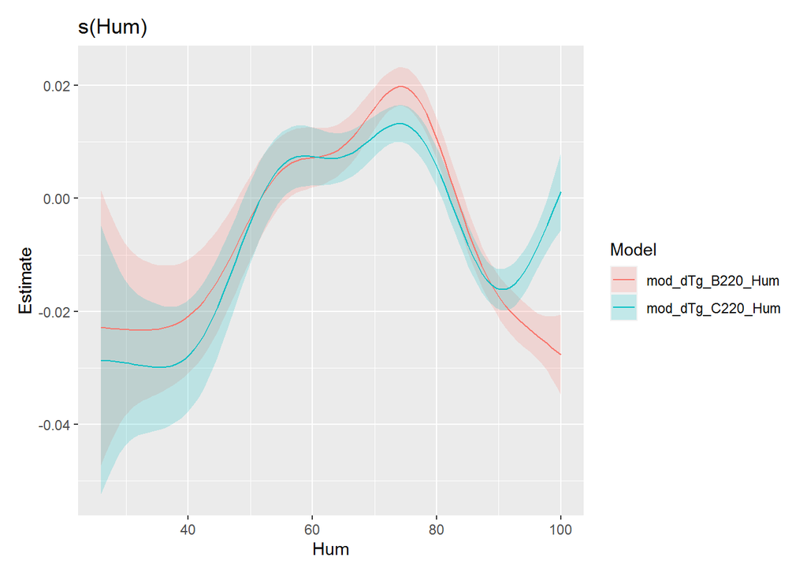

**Сторона 500 кВ**

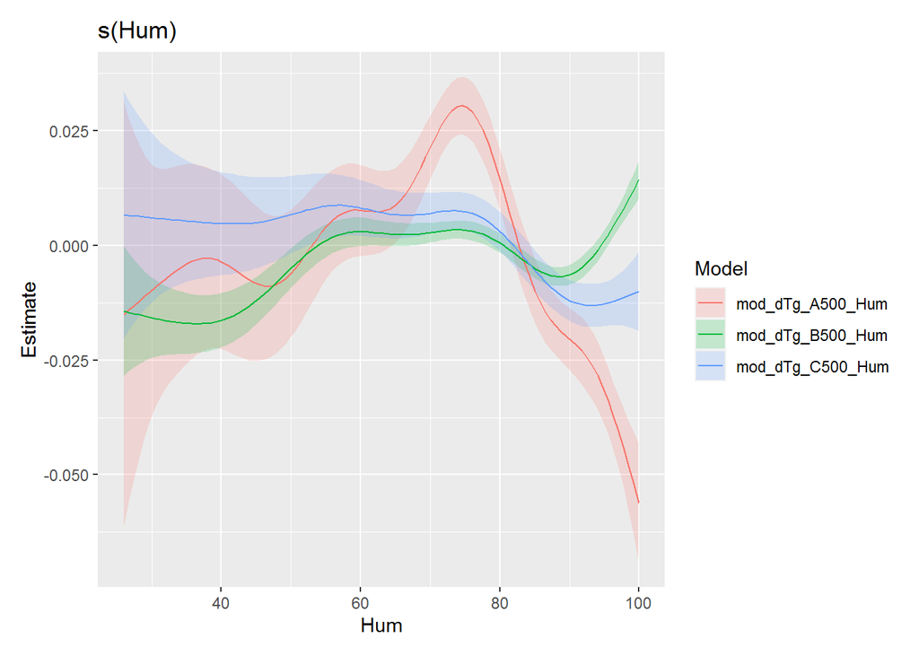

Из полученых данных не наблюдается зависимость дельта тангенса от влажности весь разброс составляет порядка 0,05 %.

Исходя из полученных результатов можно предположить следующие выводы:

1. Дельта емкость высоковольтных вводов с RIP изоляцией имеет зависимость:

   - от температуры окружающей среды до 3,5 %

   - от влажности воздуха в диапазоне до 1%

   Данные показатели являются весомой долей в диапазоне формирования сигнализации при он-лайн мониторинге, что в свою очередь требует учета данных зависимостей в современнных устройствах контроля высоковольтных вводов для повышения достоверности и исключения ложных срабатываний.
2. Зависимость дельта тангенса от температуры и влажности практически отсутствует на чистых вводах и начинает существенно проявляться по мере загрязнения высоковольтного ввода.